# 迴歸模型（Regression）

郭耀仁

2017-08-04

## 常見的機器學習問題

- 監督式學習
  - 迴歸模型（*）
  - 分類模型
- 非監督式學習
  - 分群模型

## 氣溫與冰紅茶銷量

- 氣溫與飲料店冰紅茶銷量的關係為何?
- 先畫一個散佈圖

Data source: [世界第一簡單統計學](http://www.books.com.tw/products/0010695099)

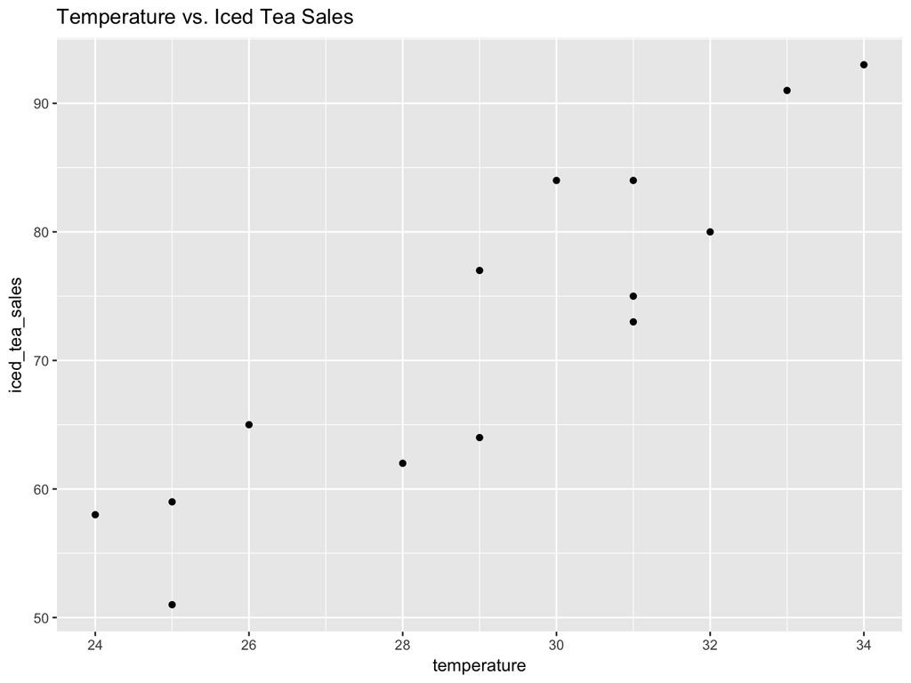

```r
library(ggplot2)

temperature <- c(29, 28, 34, 31, 25, 29, 32, 31, 24, 33, 25, 31, 26, 30)
iced_tea_sales <- c(77, 62, 93, 84, 59, 64, 80, 75, 58, 91, 51, 73, 65, 84)
iced_tea_df <- data.frame(temperature, iced_tea_sales)
ggplot(iced_tea_df, aes(x = temperature, y = iced_tea_sales)) +
  geom_point() +
  ggtitle("Temperature vs. Iced Tea Sales")
```

## 氣溫與冰紅茶銷量（2）

- 真實的氣溫與冰紅茶銷量的關係：

$$y = f(x)$$

- 但沒有人知道 $f$ 到底是什麼，我們只能假設氣溫與冰紅茶銷量的關係是：

$$\hat{y} = h(x)$$

## 氣溫與冰紅茶銷量（3）

- 當 $\hat{y}$ 與 $y$ 之間的差異愈小，我們就可以更有自信地說 $h$ 跟 $f$ 愈相似

$$\text{minimize:} \frac{1}{2m}\sum_{i=1}^{m}(\hat{y_i}-y_i)^2$$

## 氣溫與冰紅茶銷量（4）

- 我們將 $h(x)$ 寫得更仔細一點：

$$h(x) = \theta_0 + \theta_1 x_1$$

## 氣溫與冰紅茶銷量（5）

- 任務：找到一組 $(\theta_0, \theta_1)$ 能讓 $\hat{y}$ 與 $y$ 之間的差異最小

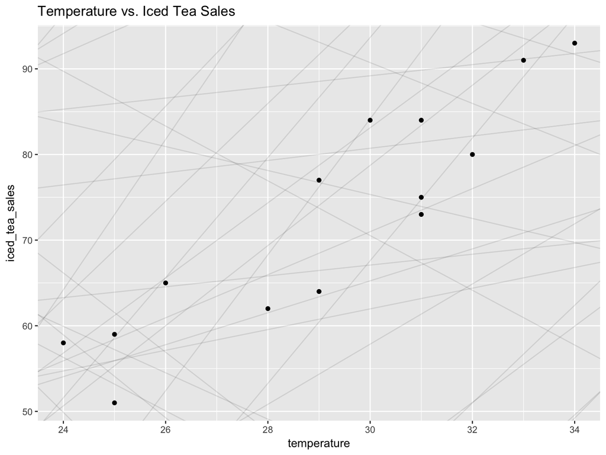

## 氣溫與冰紅茶銷量（6）

- 任務：找到一組 $(\theta_0, \theta_1)$ 能讓 $\hat{y}$ 與 $y$ 之間的差異最小

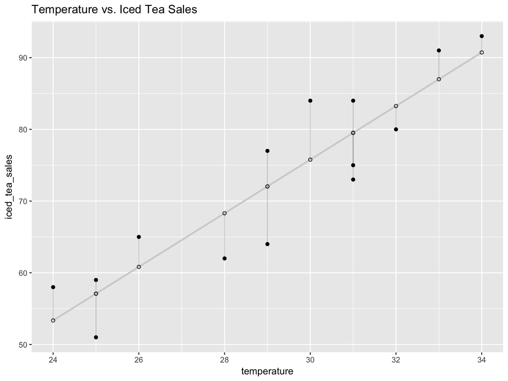

## 氣溫與冰紅茶銷量（6）

- 透過兩種方式找到 $(\theta_0, \theta_1)$ 完成任務：
  - Gradient Descent
  - Normal Equation

## 氣溫與冰紅茶銷量（7）

- Gradient Descent

> 每組 $(\theta_0, \theta_1)$ 所得的成本函數微分取得斜率，利用這個斜率逐步取得局部最佳解的方法。

## 氣溫與冰紅茶銷量（8）

- 如果只有 $\theta_1$：

$$\theta_1 := \theta_1 - \alpha \frac{\mathrm \partial}{\mathrm \partial \theta_1} J(\theta_1)$$

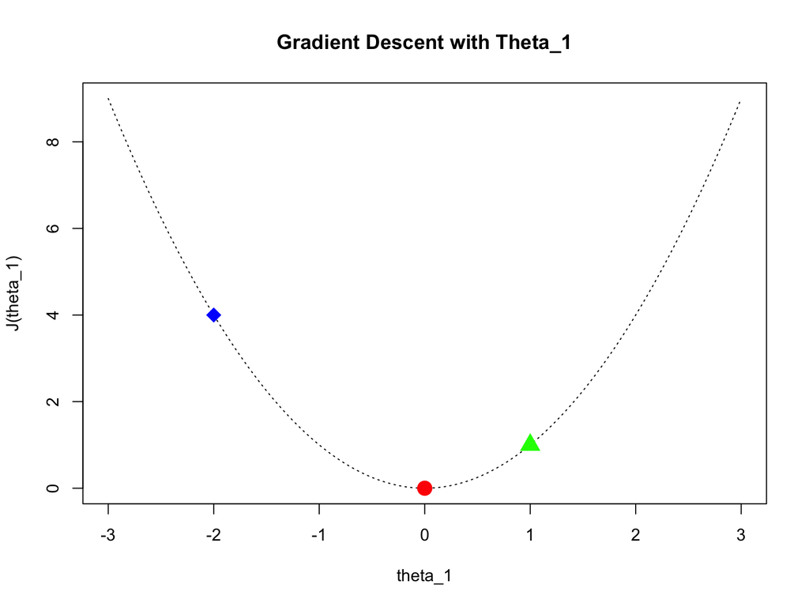

## 氣溫與冰紅茶銷量（9）

- $\theta_1$ 修正的速度與 $\alpha$ 相關
  - $\alpha$ 稱為學習速率

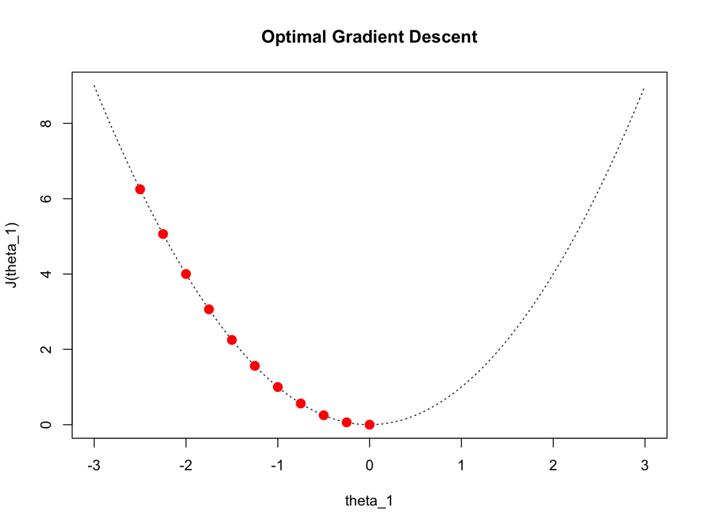

## 氣溫與冰紅茶銷量（10）

- 如果是 $(\theta_0, \theta_1)$：

$$\theta_0 := \theta_0 - \alpha \frac{\mathrm \partial}{\mathrm \partial \theta_0} J(\theta)$$

$$\theta_1 := \theta_1 - \alpha \frac{\mathrm \partial}{\mathrm \partial \theta_1} J(\theta)$$

## 氣溫與冰紅茶銷量（11）

- 如果是 $(\theta_0, \theta_1)$：

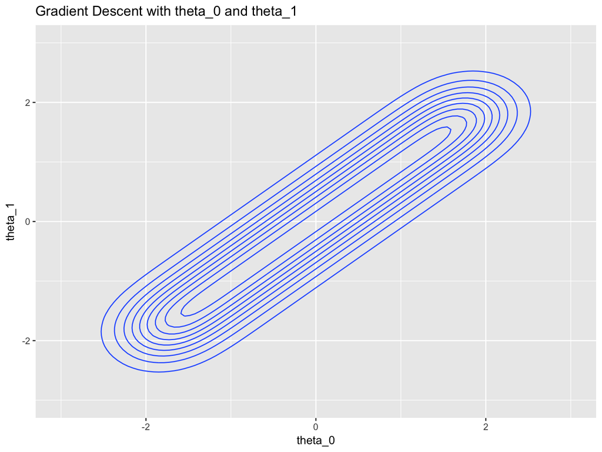

## 氣溫與冰紅茶銷量（12）

- $x_i$ 的個數增加，表示用更多的特徵（features）來建立**假設**：

$$h(x) = \theta_0 + \theta_1 x_1 + \theta_2 x_2 + ... + \theta_n x_n$$

- 假如我們令 $x_0 = 1$，就可以將式子廣義地表示為：

$$h(x) = \begin{bmatrix} \theta_0 & \theta_1 & ... & \theta_n \end{bmatrix} \begin{bmatrix} x_0 \\ x_1 \\.\\.\\.\\ x_n \end{bmatrix} = \theta^{T}x$$

## 氣溫與冰紅茶銷量（13）

- Normal Equation 求解：

$$J(\theta) = \frac{1}{2m}(X\theta - y)^T(X\theta - y)$$

$$J(\theta) = ((X\theta)^T - y^T)(X\theta - y)$$
$$J(\theta) = (X\theta)^TX\theta - (X\theta)^Ty - y^T(X\theta) + y^Ty$$
$$J(\theta) = \theta^TX^TX\theta - 2(X\theta)^Ty + y^Ty$$

$$\frac{\mathrm \partial}{\mathrm \partial \theta} J(\theta) = 2X^TX\theta-2X^Ty = 0$$

$$\theta = (X^TX)^{-1}X^Ty$$

## 氣溫與冰紅茶銷量（14）

- 評估迴歸模型的指標：
1. RMSE（愈低愈好）

$$RMSE = \sqrt{\frac{1}{N}\sum_{i=1}^N(y_i - \hat{y}_i) ^ 2}$$

2. R-squared（愈接近 1 愈好，複迴歸改為使用 `adj.r.squared`）

## 氣溫與冰紅茶銷量（15）

- 將資料集切割為訓練、測試

```r
# train_test_split()
train_test_split <- function(x, train_size = 0.7){
  n_row <- nrow(x)
  shuffled_order <- sample(1:n_row)
  x_shuffled <- x[shuffled_order, ]
  cut_point <- round(n_row * train_size)
  train_data <- x_shuffled[1:cut_point, ]
  test_data <- x_shuffled[(cut_point + 1):n_row,]
  return(list(
    train = train_data,
    test = test_data
  ))
}
```

## 氣溫與冰紅茶銷量（16）

- 使用 `lm()` 函數找出 $h$

```r
temperature <- c(29, 28, 34, 31, 25, 29, 32, 31, 24, 33, 25, 31, 26, 30)
iced_tea_sales <- c(77, 62, 93, 84, 59, 64, 80, 75, 58, 91, 51, 73, 65, 84)
iced_tea_df <- data.frame(temperature, iced_tea_sales)

# Splitting
iced_tea_train_test <- train_test_split(iced_tea_df)
train <- iced_tea_train_test$train
test <- iced_tea_train_test$test

# Modeling
lm_fit <- lm(formula = iced_tea_sales ~ temperature, data = train)

# Predicting
y_hat <- predict(lm_fit, newdata = test)

# 計算 RMSE
res <- test$iced_tea_sales - y_hat
rmse <- sqrt(sum(res^2) / nrow(iced_tea_df))
rmse

# R-squared
summary_lm_fit <- summary(lm_fit)
summary_lm_fit$r.squared
```

```
## [1] 2.972997
## [1] 0.8536156
```

## 補充：如何選擇變數

## 變數選擇

- 使用 `step()` 函數

```r
library(MASS) # to get Boston df
head(Boston)

lm_fit_full <- lm(medv ~ ., data = Boston)
backwards <- step(lm_fit_full, trace = 0)
formula(backwards)
summary(backwards)
```

[output not shown]

## 變數選擇（2）

```r
lm_fit_full <- lm(medv ~ ., data = Boston)
lm_fit_null <- lm(medv ~ 1, data = Boston)
forwards <- step(lm_fit_null,
scope = list(lower = formula(lm_fit_null), upper = formula(lm_fit_full)), direction = "forward", trace = 0)
formula(forwards)
```

[output not shown]

## 變數選擇（3）

```r
lm_fit_full <- lm(medv ~ ., data = Boston)
lm_fit_null <- lm(medv ~ 1, data = Boston)
bothways <- step(lm_fit_null,
scope = list(lower = formula(lm_fit_null), upper = formula(lm_fit_full)), direction = "both", trace = 0)
formula(bothways)
```

[output not shown]